# assignment3_20182480_문지원

문지원_20182480

2021 4 10

### [Climate Change]

#### 1.Year 및 Month를 제외한 9개의 변수들 간의 상관 관계를 다양한 그래프를 활용하여 시각화해보고, 이로부터 데이터의 특성을 분석해보자

```r
# read data
Climate <- read.csv("ClimateChange.csv")
str(Climate)
```

```
## 'data.frame':    308 obs. of  11 variables:
##  $ Year    : int  1983 1983 1983 1983 1983 1983 1983 1983 1984 1984 ...
##  $ Month   : int  5 6 7 8 9 10 11 12 1 2 ...
##  $ MEI     : num  2.556 2.167 1.741 1.13 0.428 ...
##  $ CO2     : num  346 346 344 342 340 ...
##  $ CH4     : num  1639 1634 1633 1631 1648 ...
##  $ N2O     : num  304 304 304 304 304 ...
##  $ CFC.11  : num  191 192 193 194 194 ...
##  $ CFC.12  : num  350 352 354 356 357 ...
##  $ TSI     : num  1366 1366 1366 1366 1366 ...
##  $ Aerosols: num  0.0863 0.0794 0.0731 0.0673 0.0619 0.0569 0.0524 0.0486 0.0451 0.0416 ...
##  $ Temp    : num  0.109 0.118 0.137 0.176 0.149 0.093 0.232 0.078 0.089 0.013 ...
```

```r
# Remove Feature
Climate <- Climate[,-1]
Climate <- Climate[,-1]
str(Climate)
```

```
## 'data.frame':    308 obs. of  9 variables:
##  $ MEI     : num  2.556 2.167 1.741 1.13 0.428 ...
##  $ CO2     : num  346 346 344 342 340 ...
##  $ CH4     : num  1639 1634 1633 1631 1648 ...
##  $ N2O     : num  304 304 304 304 304 ...
##  $ CFC.11  : num  191 192 193 194 194 ...
##  $ CFC.12  : num  350 352 354 356 357 ...
##  $ TSI     : num  1366 1366 1366 1366 1366 ...
##  $ Aerosols: num  0.0863 0.0794 0.0731 0.0673 0.0619 0.0569 0.0524 0.0486 0.0451 0.0416 ...
##  $ Temp    : num  0.109 0.118 0.137 0.176 0.149 0.093 0.232 0.078 0.089 0.013 ...
```

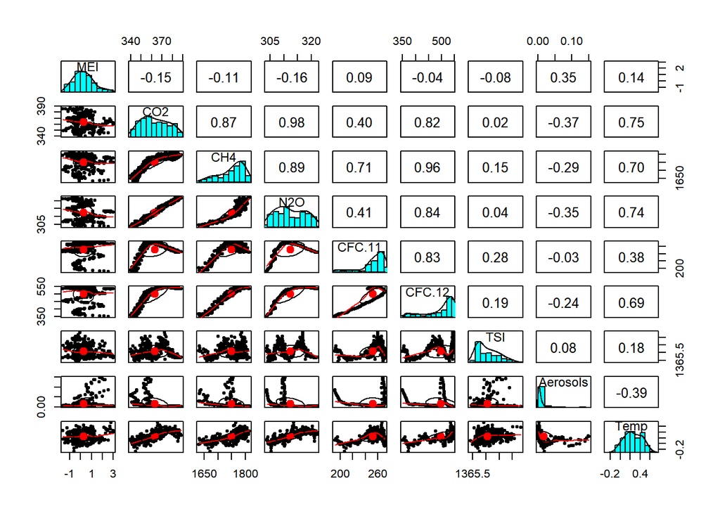

```r
# 상관관계 시각화
library(psych)
pairs.panels(Climate[c("MEI","CO2","CH4","N2O","CFC.11","CFC.12","TSI","Aerosols","Temp")])
```

#### 2. 2004년 이후의 데이터를 test set으로 2003년까지의 데이터를 training set으로 분할하자. 그리고 training set을 활용하여 linear regression model을 수립하자. 이때 8개의 feature 변수 모두 포함시킨다.

```r
# train set
Climate_train <- Climate[1:248,]

# test set
Climate_test <- Climate[249:308,]

# linear regression model
model1 <- lm(Temp~., data= Climate_train)
summary(model1)
```

```
##
## Call:
## lm(formula = Temp ~ ., data = Climate_train)
##
## Residuals:
##      Min       1Q   Median       3Q      Max
## -0.25789 -0.06259 -0.00590  0.05567  0.32702
##
## Coefficients:
##               Estimate Std. Error t value Pr(>|t|)
## (Intercept) -1.385e+02  2.333e+01  -5.939 1.00e-08 ***
## MEI          6.528e-02  6.870e-03   9.501  < 2e-16 ***
## CO2          6.632e-03  2.643e-03   2.509 0.012768 *
## CH4          2.013e-04  5.939e-04   0.339 0.734969
## N2O         -2.525e-02  1.092e-02  -2.312 0.021635 *
## CFC.11      -7.666e-03  1.972e-03  -3.887 0.000131 ***
## CFC.12       4.557e-03  1.267e-03   3.598 0.000390 ***
## TSI          1.051e-01  1.792e-02   5.866 1.48e-08 ***
## Aerosols    -1.590e+00  2.269e-01  -7.010 2.42e-11 ***
## ---
## Signif. codes:  0 '***' 0.001 '**' 0.01 '*' 0.05 '.' 0.1 ' ' 1
##
## Residual standard error: 0.09482 on 239 degrees of freedom
## Multiple R-squared:  0.7133, Adjusted R-squared:  0.7037
## F-statistic: 74.32 on 8 and 239 DF,  p-value: < 2.2e-16
```

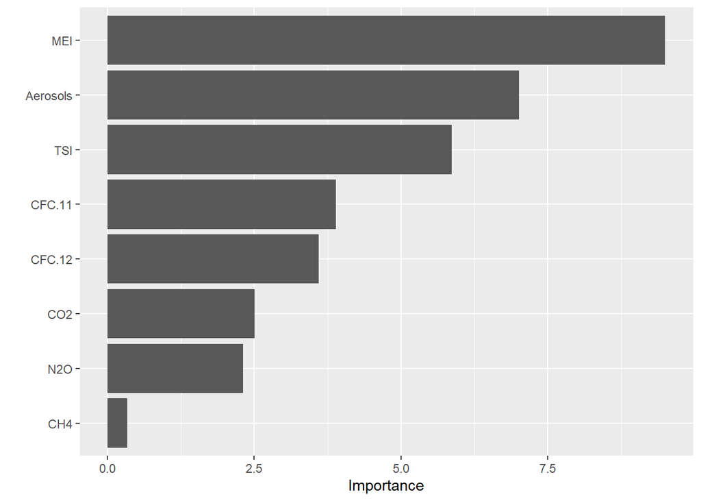

```r
# feature importance
library(vip)
vip(model1)
```

– **어떠한 feature들이 Temp에 큰 영향을 미치는가?**

MEI,Aerosols,TSI,CFC.11,CFC.12,CO2,N2O가 통계적으로 유의하며, 순서대로 Temp에 끼치는 영향도가 크다

– **N2O와 CFC-11은 지구의 지표면에서 우주로 발산하는 적외선 복사열을 흡수하여 지구 표면의 온도를 상승시키는 역할을 하는 온실가스로 알려져 있다. 모델에서 N2O와 CFC-11 변수의 coefficient는 양수 값을 가지는가? 음수 값을 가지는가? 만약 음수값을 가진다면 N2O와 CFC-11의 양이 증가할수록 평균 기온이 감소한다는 것을 의미하므로 일반적인 지식과 모순된다. 이러한 모순된 결과가 도출되는 원인은 무엇일까?**

모델에서 N20와 CFC-11 변수의 coefficient는 모두 음수 값을 가진다.따라서 N2O와 CFC-11양이 증가할수록 평균기온이 감소한다는 것을 의미하는데 이는 일반적인 지식과 모순된다.이러한 모순된 결과가 도출되는 원인은 다른 양의 coefficient 값을 가지는 변수들의 영향력이 더 강하기 때문일 것이라고 생각한다.

#### 3. MEI, TSI, Aerosols, N2O 4개의 feature만 사용하여 regression model을 만들어보자.

```r
model2 <- lm(Temp ~ MEI+TSI+Aerosols+N2O, data=Climate_train)
summary(model2)
```

```
##
## Call:
## lm(formula = Temp ~ MEI + TSI + Aerosols + N2O, data = Climate_train)
##
## Residuals:
##      Min       1Q   Median       3Q      Max
## -0.27840 -0.05990 -0.00633  0.05624  0.34294
##
## Coefficients:
##               Estimate Std. Error t value Pr(>|t|)
## (Intercept) -1.169e+02  2.315e+01  -5.052 8.58e-07 ***
## MEI          6.492e-02  7.089e-03   9.158  < 2e-16 ***
## TSI          8.003e-02  1.712e-02   4.674 4.89e-06 ***
## Aerosols    -1.708e+00  2.290e-01  -7.459 1.54e-12 ***
## N2O          2.524e-02  1.811e-03  13.933  < 2e-16 ***
## ---
## Signif. codes:  0 '***' 0.001 '**' 0.01 '*' 0.05 '.' 0.1 ' ' 1
##
## Residual standard error: 0.09935 on 243 degrees of freedom
## Multiple R-squared:  0.6799, Adjusted R-squared:  0.6747
## F-statistic: 129.1 on 4 and 243 DF,  p-value: < 2.2e-16
```

– **N2O 변수의 coefficient를 2번 모델과 비교해 보자.**

N2O 변수의 끼치는 영향력이 2번 모델보다 커졌다.

– **두 모델의 R squred 값, Adjusted R squared 값, test set error (test set에 대한 RMSE)를 비교해보자. 어떤 모델을 선택하겠는가?**

R-squared 는 회귀모델에서 독립변수가 종속변수를 얼마만큼 설명해 주는지를 가리키는 지표이다. 따라서 독립변수의 수가 증가하면 상승한다. 그러나 종속변수를 잘 설명하지 못하는 변수가 추가되어도 증가하기 때문에 Adjusted R-sqaured 값을 이용한다. Adjusted R-Squared 값은 독립변수의 개수가 증가하더라도 일방적인 증가를 방지한다.

2번 모델에서는 R-squared 값이 0.7133, Adjusted R-squared 값이 0.7037이다. 3번 모델에서는 R-squared 값이 0.6799, Adjusted R-squared 값이 0.6747이다.

두 모델의 R-Squared 값을 비교했을 때, 3번 모델이 feature 개수가 4개로 줄어들어 모델이 훨씬 단순해졌음에도 Adjusted R-Squared 값에 큰 차이가 없다. 또한 미래의 데이터에 대한 예측을 하는 test error는 Adjusted R-squared 값과 반비례하는 경향이 있다. 따라서 test error는 2번 문제보다 3번문제에서 더 클 것이라고 예측할 수 있다. 그러나 두 모델의 Adjusted R-squared 값이 차이가 크지 않기 때문에 test error의 차이도 크지 않다. 따라서단순성과 정확성 모두를 고려하였을 때 3번과 같은 feature 4개가 포함된 모델을 선택할 것이다.

#### 4. 8개의 feature를 대상으로 cross validation을 활용한 stepwise variable selection을 수행해보자.

```r
library(caret)
library(leaps)
# Forward Stepwise selection
set.seed(123)
fwd_model4 <- train(Temp~., data= Climate_train, method="leapForward", tuneGrid = data.frame(nvmax= 1:9),trControl=trainControl(method="repeatedcv",number=10,repeats = 5))

fwd_model4
```

```
## Linear Regression with Forward Selection
##
## 248 samples
##   8 predictor
##
## No pre-processing
## Resampling: Cross-Validated (10 fold, repeated 5 times)
## Summary of sample sizes: 222, 224, 223, 223, 224, 223, ...
## Resampling results across tuning parameters:
##
##   nvmax  RMSE        Rsquared   MAE
##   1      0.11373146  0.5903815  0.09022930
##   2      0.10726659  0.6339283  0.08558404
##   3      0.10141429  0.6791024  0.08172280
##   4      0.09687903  0.7058610  0.07685017
##   5      0.09715924  0.7043747  0.07709111
##   6      0.09543978  0.7144510  0.07509775
##   7      0.09450971  0.7163120  0.07491875
##   8      0.09499221  0.7134394  0.07518414
##   9      0.09499221  0.7134394  0.07518414
##
## RMSE was used to select the optimal model using the smallest value.
## The final value used for the model was nvmax = 7.
```

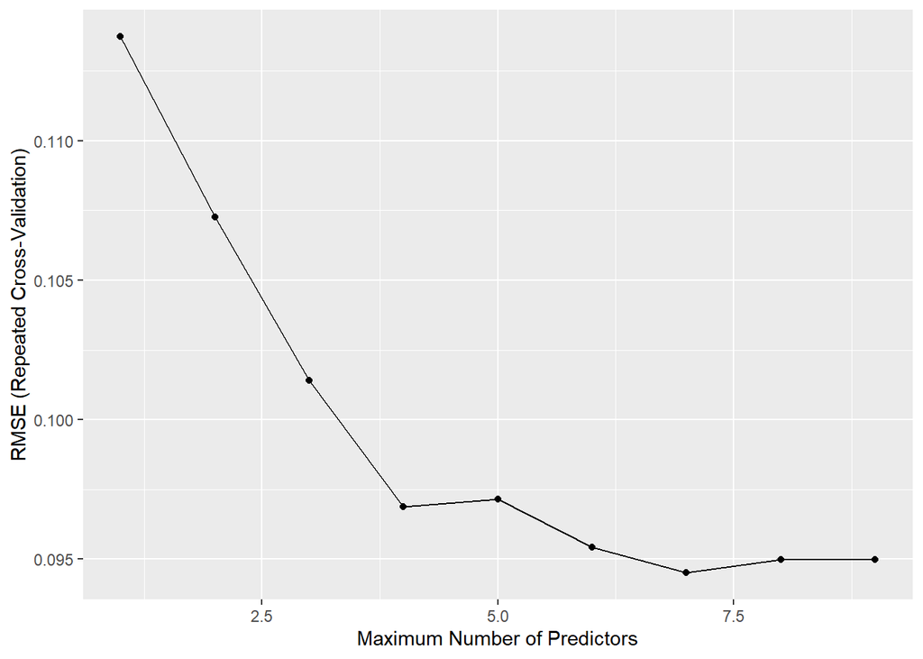

```r
ggplot(fwd_model4)
```

```r
# Backward Stepwise Selection
set.seed(123)
bwd_model4 <- train(Temp~., data= Climate_train, method="leapBackward", tuneGrid = data.frame(nvmax= 1:9),trControl=trainControl(method="repeatedcv",number=10,repeats = 5))

bwd_model4
```

```
## Linear Regression with Backwards Selection
##
## 248 samples
##   8 predictor
##
## No pre-processing
## Resampling: Cross-Validated (10 fold, repeated 5 times)
## Summary of sample sizes: 222, 224, 223, 223, 224, 223, ...
## Resampling results across tuning parameters:
##
##   nvmax  RMSE        Rsquared   MAE
##   1      0.13097046  0.4475973  0.10308686
##   2      0.11675834  0.5636173  0.09188947
##   3      0.10941267  0.6183794  0.08668517
##   4      0.10269927  0.6681563  0.08226994
##   5      0.09580773  0.7109532  0.07545329
##   6      0.09638052  0.7078080  0.07590022
##   7      0.09450971  0.7163120  0.07491875
##   8      0.09499221  0.7134394  0.07518414
##   9      0.09499221  0.7134394  0.07518414
##
## RMSE was used to select the optimal model using the smallest value.
## The final value used for the model was nvmax = 7.
```

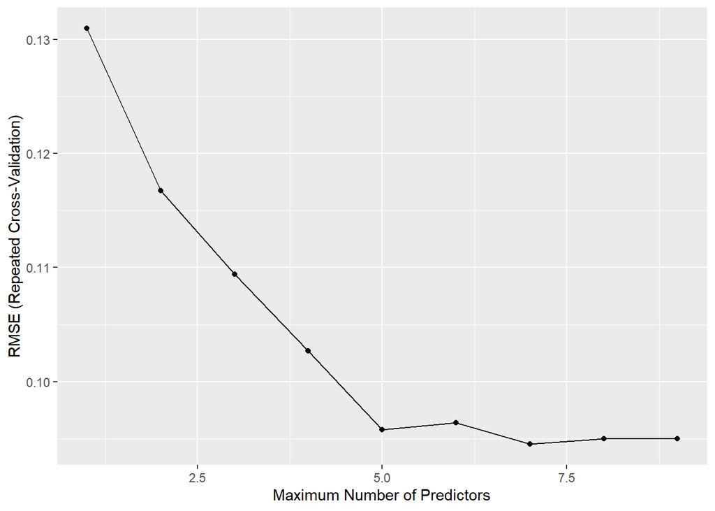

```r
ggplot(bwd_model4)
```

```r
# forward selection의 coefficient
coef_fwd_cv4 <- coef(fwd_model4$finalModel,fwd_model4$bestTune$nvmax)
coef_fwd_cv4
```

```
##   (Intercept)           MEI           CO2           N2O        CFC.11
## -1.376198e+02  6.507260e-02  6.578998e-03 -2.401335e-02 -7.564601e-03
##        CFC.12           TSI      Aerosols
##  4.603344e-03  1.043919e-01 -1.591637e+00
```

– **Forward selection과 backward selection의 결과를 비교해보자**

Forward selection과 backward selection에서의 nvmax 결과가 동일하다.

– **Prediction accuracy와 Model interpretability를 종합적으로 고려하여 best모델을 하나 결정하자.**

Predition Accuracy와 Model Interpretability를 모두 고려할 때 적은 feature 수로 높은 성능을 갖는 모델을 결정하는 것이 좋다. Forward와 Backward selection 모두 7개의 feature를 선택한다는 결론이 나왔기 때문에 아무거나 선택해주었다.

#### 5. Prediction accuracy를 높이기 위해, 기존 8개의 feature들 외에 feature들 사이의 모든 iteraction effect, 그리고 CO2, CFC.11, CFC.12의 제곱항들을 모두 추가한 모델을 대상으로 cross validation을 활용한 stepwise variable selection을 수행해보자.

```r
# Forward selection
set.seed(123)
fwd_model5 <- train(Temp~(.)^2+I(CO2^2)+I(CFC.11^2)+I(CFC.12^2), data= Climate_train, method="leapForward",tuneGrid= data.frame(nvmax = 1:40), trControl = trainControl(method="repeatedcv",number =10, repeats = 5))

fwd_model5
```

```
## Linear Regression with Forward Selection
##
## 248 samples
##   8 predictor
##
## No pre-processing
## Resampling: Cross-Validated (10 fold, repeated 5 times)
## Summary of sample sizes: 222, 224, 223, 223, 224, 223, ...
## Resampling results across tuning parameters:
##
##   nvmax  RMSE        Rsquared   MAE
##    1     0.11391373  0.5888669  0.09043463
##    2     0.10733591  0.6332972  0.08575455
##    3     0.10048120  0.6841432  0.08116742
##    4     0.09686374  0.7050144  0.07725763
```

[output cut: 39 more lines]

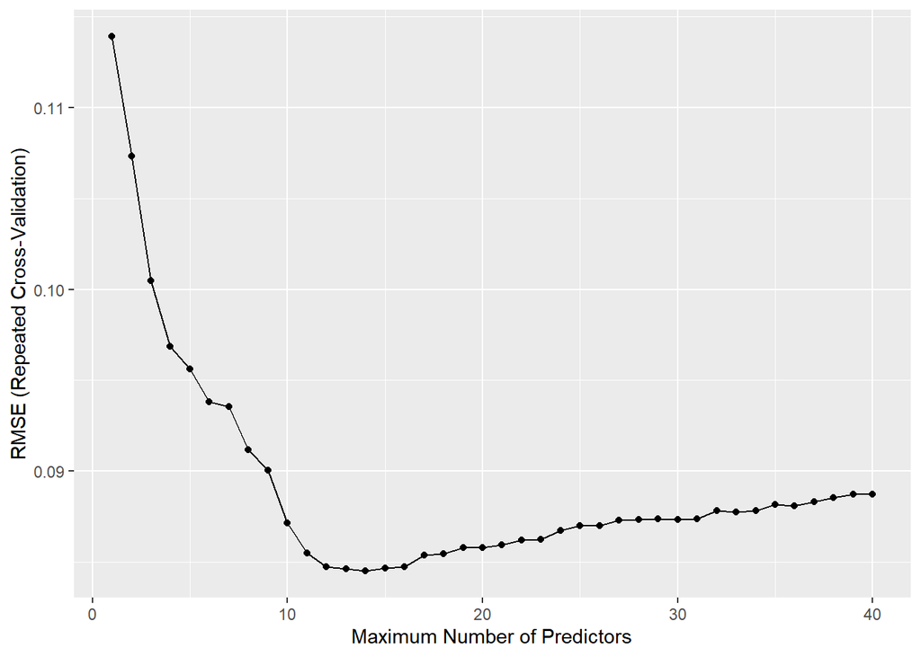

```r
ggplot(fwd_model5)
```

```r
# Backward selection
set.seed(123)
bwd_model5 <- train(Temp~(.)^2+I(CO2^2)+I(CFC.11^2)+I(CFC.12^2), data= Climate_train, method="leapBackward",tuneGrid= data.frame(nvmax = 1:40), trControl = trainControl(method="repeatedcv",number =10, repeats = 5))

bwd_model5
```

```
## Linear Regression with Backwards Selection
##
## 248 samples
##   8 predictor
##
## No pre-processing
## Resampling: Cross-Validated (10 fold, repeated 5 times)
## Summary of sample sizes: 222, 224, 223, 223, 224, 223, ...
## Resampling results across tuning parameters:
##
##   nvmax  RMSE        Rsquared   MAE
##    1     0.13125765  0.4458752  0.10343957
##    2     0.11860230  0.5532065  0.09350733
##    3     0.11129866  0.6071414  0.08860355
##    4     0.10392228  0.6618165  0.08360050
```

[output cut: 39 more lines]

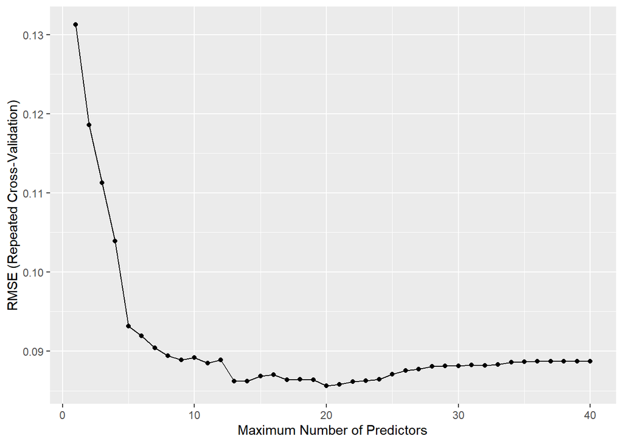

```r
ggplot(bwd_model5)
```

```r
# Rmse가 더 작은 Forward Selection 의 coefficient
coef_fwd_cv5 <- coef(fwd_model5$finalModel,fwd_model5$bestTune$nvmax)
coef_fwd_cv5
```

```
##     (Intercept)             TSI        I(CO2^2)     I(CFC.11^2)     I(CFC.12^2)
##    2.032372e+01   -3.893144e-02   -3.880279e-04   -1.448747e-04   -9.674515e-05
##         MEI:CO2      MEI:CFC.11      CO2:CFC.12         CO2:TSI    CO2:Aerosols
##   -1.515015e-03    2.343990e-03    1.810998e-04    1.420082e-04    1.332920e-01
##    CH4:Aerosols      N2O:CFC.11   CFC.11:CFC.12 CFC.11:Aerosols CFC.12:Aerosols
##   -1.374178e-02   -4.613255e-05    1.443868e-04    6.635628e-01   -4.048055e-01
```

– **Forward selection과 backward selection의 결과를 비교해보자**

Forward selection에서는 14개의 feature를 선택, backward selection에서는 20개의 feature를 선택한다.

– **Cross validated RMSE가 가장 낮은 best모델을 결정하자. 어떠한 변수들이 best 모델에 포함되는가**

Forward selection에서 nvmax가 14일때 RMSE가 0.0845, backward selection에서 nvmax가 20일때 0.0856 이므로 Forward selection에서 nvmax가 14일때 cross validated RMSE가 가장 낮다.

#### 6. 2,3,4,5번에서 수립된 4개의 모델에 대해서 test set (2004년 이후 데이터)에 대한 prediction accuracy(RMSE)를 비교해보자. 예상한 대로 결과가 나오는가? 그렇지 않다면 그 원인은 무엇일지 분석해보자.

```r
# No2 RMSE
pred_model2 <- predict(model1,Climate_test)
RMSE(pred_model2, Climate_test$Temp)
```

```
## [1] 0.08439069
```

```r
# No3 RMSE
pred_model3 <- predict(model2, Climate_test)
RMSE(pred_model3,Climate_test$Temp)
```

```
## [1] 0.08501107
```

```r
# No4 RMSE
pred_model4_fwd <- predict(fwd_model4,Climate_test)
RMSE(pred_model4_fwd,Climate_test$Temp)
```

```
## [1] 0.08359067
```

```r
# No5 RMSE
pred_model5_fwd <- predict(fwd_model5,Climate_test)
RMSE(pred_model5_fwd,Climate_test$Temp)
```

```
## [1] 0.09371814
```

– **결과 해석**

예상한바와 다르다. 8개의 feature들의 iteraction을 고려하고 model selection을 한 5번 문제에서 가장 RMSE가 낮을 것이라 예측했었는데 제일 RMSE가 높은 결과가 나왔다.

아마도 이러한 원인은 Model에 포함된 feature의 수가 너무 많아, model 복잡도가 높아져 variance가 급격하게 증가하여 overfitting이 발생했기 때문이다.

### [Regression on Simulated Data]

#### 랜덤 데이터 생성

```r
# vector X 생성
set.seed(1)
X <- rnorm(200,0,1)

# vector E 생성
set.seed(2)
E <- rnorm(200,0,4)

# target vector Y 생성
Y <- 1+2*X-3*X^2+4*X^3+E
```

#### 1.X,X2,X3…X10 의 10개 변수를 feature로, Y를 target으로 설정하자. 이때 feature 변수들과 target변수 사이의 상관관계를 시각화해보자.

```r
# data frame 생성
df <- data.frame(X,X^2,X^3,X^4,X^5,X^6,X^7,X^8,X^9,X^10,Y)
str(df)
```

```
## 'data.frame':    200 obs. of  11 variables:
##  $ X   : num  -0.626 0.184 -0.836 1.595 0.33 ...
##  $ X.2 : num  0.3924 0.0337 0.6983 2.5449 0.1086 ...
##  $ X.3 : num  -0.24585 0.00619 -0.5835 4.05986 0.03578 ...
##  $ X.4 : num  0.15401 0.00114 0.48759 6.47662 0.01179 ...
##  $ X.5 : num  -0.096482 0.000209 -0.407443 10.332031 0.003884 ...
##  $ X.6 : num  6.04e-02 3.84e-05 3.40e-01 1.65e+01 1.28e-03 ...
##  $ X.7 : num  -3.79e-02 7.04e-06 -2.85e-01 2.63e+01 4.22e-04 ...
##  $ X.8 : num  2.37e-02 1.29e-06 2.38e-01 4.19e+01 1.39e-04 ...
##  $ X.9 : num  -1.49e-02 2.38e-07 -1.99e-01 6.69e+01 4.58e-05 ...
##  $ X.10: num  9.31e-03 4.36e-08 1.66e-01 1.07e+02 1.51e-05 ...
##  $ Y   : num  -6 2.03 1.25 8.27 1.16 ...
```

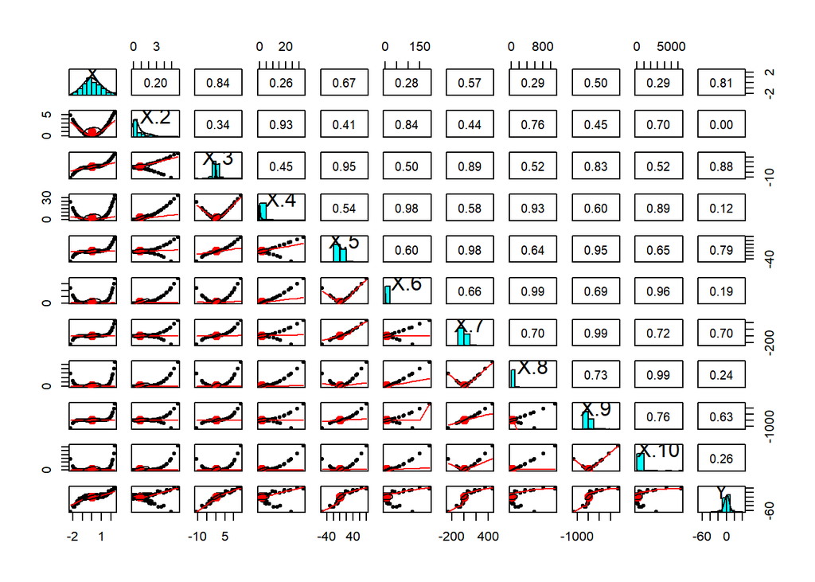

```r
# 상관관계 시각화
pairs.panels(df[c("X","X.2","X.3","X.4","X.5","X.6","X.7","X.8","X.9","X.10","Y")])
```

– **결과 해석**

X와 Y의 상관계수는 0.81로 상관성이 높다.  
X.2와 Y는 상관계수가 0이므로 상관성이 없다.  
X.3과 Y의 상관계수는 0.88로 상관성이 높다.  
X.4와 Y의 상관계수는 0.12로 상관성이 낮다.  
X.5과 Y의 상관계수는 0.79로 상관성이 높다.  
X.6과 Y의 상관계수는 0.19로 상관성이 낮다.  
X.7과 Y의 상관계수는 0.7로 상관성이 높다.  
X.8과 Y의 상관계수는 0.24로 상관성이 낮다.  
X.9와 Y의 상관계수는 0.63으로 상관성이 높다.  
X.10과 Y의 상관계수는 0.26으로 상관성이 낮다.

#### 2. 10개의 feature를 모두 포함하는 linear regression model을 만들어보자. 통계적으로 유의한 변수가 있는가? regression coefficient B hat 값을 실제 B와 비교해보자.

```r
# train test split
library(rsample)

# linear regression
model2_2 <- lm(Y~., data= df)
summary(model2_2)
```

```
##
## Call:
## lm(formula = Y ~ ., data = df)
##
## Residuals:
##     Min      1Q  Median      3Q     Max
## -9.8414 -2.8479 -0.2324  3.0002  9.6018
##
## Coefficients:
##             Estimate Std. Error t value Pr(>|t|)
## (Intercept)  1.15784    0.61600   1.880   0.0617 .
## X            4.22907    1.80721   2.340   0.0203 *
## X.2         -2.88520    3.95085  -0.730   0.4661
## X.3         -4.53874    4.93826  -0.919   0.3592
## X.4          3.15482    6.27799   0.503   0.6159
## X.5          7.77933    3.92448   1.982   0.0489 *
## X.6         -3.73149    3.70580  -1.007   0.3153
## X.7         -2.42817    1.15599  -2.101   0.0370 *
## X.8          1.22634    0.89713   1.367   0.1733
## X.9          0.24128    0.11235   2.148   0.0330 *
## X.10        -0.12268    0.07573  -1.620   0.1069
## ---
## Signif. codes:  0 '***' 0.001 '**' 0.01 '*' 0.05 '.' 0.1 ' ' 1
##
## Residual standard error: 4.274 on 189 degrees of freedom
## Multiple R-squared:  0.8893, Adjusted R-squared:  0.8835
## F-statistic: 151.9 on 10 and 189 DF,  p-value: < 2.2e-16
```

– **결과 해석**

통계적으로 유의한 변수는 X,X.5,X.7,X.9이다. regression coefficient 값을 실제와 비교했을 때 같다고 말할 수 없다.

#### 3. X,X2,X3의 3개 변수를 feature로, Y를 target으로 linear regression model을 만들엉보자. 모든 feature들이 통계적으로 유의한가? regression coefficient B hat 값을 실제 B와 비교해보자.

```r
# 새로운 데이터 프레임 생성
df2 <- data.frame(X,X^2,X^3,Y)

# linear regression
model2_3 <- lm(Y~., data= df2)
summary(model2_3)
```

```
##
## Call:
## lm(formula = Y ~ ., data = df2)
##
## Residuals:
##      Min       1Q   Median       3Q      Max
## -10.2696  -3.1308  -0.2687   3.0923   9.9022
##
## Coefficients:
##             Estimate Std. Error t value Pr(>|t|)
## (Intercept)   1.4734     0.3810   3.868 0.000149 ***
## X             2.1576     0.6029   3.579 0.000435 ***
## X.2          -3.5611     0.2820 -12.629  < 2e-16 ***
## X.3           4.0029     0.2175  18.400  < 2e-16 ***
## ---
## Signif. codes:  0 '***' 0.001 '**' 0.01 '*' 0.05 '.' 0.1 ' ' 1
##
## Residual standard error: 4.281 on 196 degrees of freedom
## Multiple R-squared:  0.8849, Adjusted R-squared:  0.8831
## F-statistic: 502.2 on 3 and 196 DF,  p-value: < 2.2e-16
```

– **결과 해석**

모든 변수들이 통계적으로 유의하다는 결론이 나왔다. 또한 coefficient 값이 실제(1,2,-3,4)와 유사하다고 볼 수 있다.

#### 4. X,X2,…X10의 10개 변수를 feature로, Y를 target으로 Lasso regression model을 만들어 본다. Cross Validation으로 최적의 모델을 찾아보자. 이 모델에는 어떤 변수가 포함되었는가? regression coefficient 값을 실제 B값과 비교해보자. 그리고 결과를 바탕으로 Lasso regression의 효과에 대해서 설명해보자.

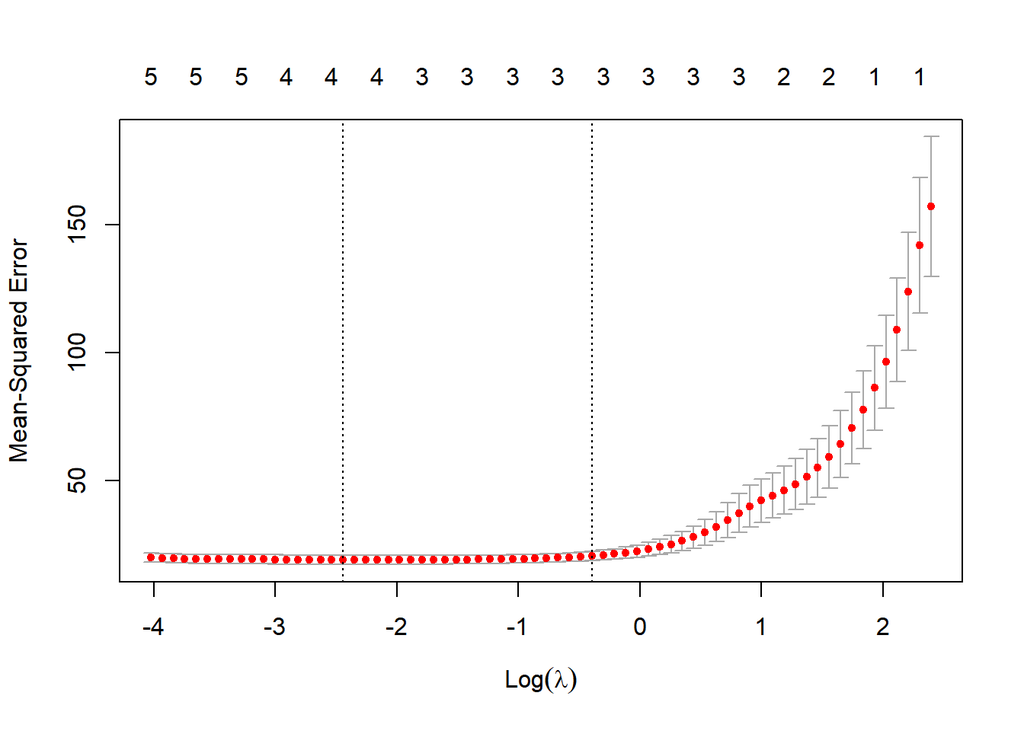

```r
library(glmnet)

# feature matrix 생성
featureX <- model.matrix(Y~.,df)[,-1]
targetY <- df$Y

# lasso regression에대한 cross validation
set.seed(123)
cv_lasso <- cv.glmnet(x=featureX, y=targetY, alpha=1, nfolds=10 )
plot(cv_lasso)
```

```r
cv_lasso
```

```
##
## Call:  cv.glmnet(x = featureX, y = targetY, nfolds = 10, alpha = 1)
##
## Measure: Mean-Squared Error
##
##     Lambda Index Measure    SE Nonzero
## min 0.0870    53   19.07 1.822       4
## 1se 0.6733    31   20.64 1.792       3
```

```r
# find best lambda
best_lambda_lasso <- cv_lasso$lambda.min
best_lambda_lasso
```

```
## [1] 0.08696225
```

```r
# final model
lasso_full <- glmnet(x=featureX, y= targetY, alpha=1)
predict(lasso_full,s=best_lambda_lasso,type="coefficients")[1:11,]
```

```
## (Intercept)           X         X.2         X.3         X.4         X.5
##  1.36361792  2.13714196 -3.37212233  3.96502461 -0.02050036  0.00000000
##         X.6         X.7         X.8         X.9        X.10
##  0.00000000  0.00000000  0.00000000  0.00000000  0.00000000
```

– **결과 해석**

이 모델에는 변수 X, X^2, X^3, X^4 가 선택되어있다. 추정된 coefficient는 (1.363,2.137,-3.372,3.965,-0.02) 이며 실제(1,2,-3,4,0)과 매우 유사하다. 따라서 올바른 variable selection을 수행했다고 볼 수 있다.